# Downloading windspeed data from NOAA

Maricar L. Rabonza

11/5/2020

## Load windspeed data

To create a damage model for this typhoon event, we need wind speed values for all municipalities of our study area. Here, we download windspeeds at 10 meter elevation from the [NOAA/NCEP Global Forecast System (GFS) Atmospheric Model](https://www.ncdc.noaa.gov/data-access/model-data/model-datasets/global-forcast-system-gfs) using the [rWind](https://cran.r-project.org/web/packages/rWind/index.html) package, and extract the average/ maximum wind speed value at the location of each municipality. In the end, we produce a CSV file listing all municipalities and the assigned windspeed in km/h.

This code needs a shapefile `PH_municipality.shp` in the folder `/Data/`. This shapefile contains the polygons of all municipalities with associated attributes.

```r
# Set working libraries
library(here) # sets location of .RProj as working directory
library(knitr) # useful for many rmarkdown layout functions
library(ggplot2) # the ultimate plotting package
library(dplyr) # best for data wrangling
library(rWind)  # help(rWind)
library(raster)
library(rworldmap)
library(rworldxtra)
library(mapproj)
library(shape)
library(sp)
library(rgdal)
library(rgeos)
library(mapview)
library(maptools)
library(scico) # colour palettes based on the scientific colour-maps
library(kableExtra) # table formatting for knitr
```

First, download windspeed for Philippines when Typhoon Goni made landfall at November 1, 2020, 00:00:00

```r
wind_data <- wind.dl(2020,11,01, 0, 109.5, 134.0, 1.5, 26.0)
```

```
## [1] "2020-11-01"
## [1] "2020-11-01 downloading..."
```

```r
wind_data <- wind_data[,c(-1,-4,-5, -6)]# delete columns we don't need: time, u&v wind, wind direction
head(wind_data) %>% # show table
  kbl(caption = "Wind velocity at 10m (2020-11-01 T 00:00:00Z)" ) %>%
  kable_classic(full_width = F, html_font = "Cambria")
```

Wind velocity at 10m (2020-11-01 T 00:00:00Z)

|  | lat | lon | speed |
| --- | --- | --- | --- |
| 2451 | 26 | 109.5 | 1.6331945 |
| 2452 | 26 | 110.0 | 0.0849805 |
| 2453 | 26 | 110.5 | 1.1139736 |
| 2454 | 26 | 111.0 | 2.3276267 |
| 2455 | 26 | 111.5 | 1.5538277 |
| 2456 | 26 | 112.0 | 1.2980874 |

The raw windspeed values are in m/s, so we convert it to km/h.

```r
wind_data$speed <- wind_data$speed * 3.6
```

## Visualize wind speed data

Now we make a map of the windspeed dataset.

```r
# Download coastlines
download.file("http://www.naturalearthdata.com/http//www.naturalearthdata.com/download/10m/physical/ne_10m_coastline.zip",
              destfile = 'coastlines.zip')
unzip(zipfile = "coastlines.zip", exdir = 'ne-coastlines-10m') # unzip the file
coastlines <- readOGR("ne-coastlines-10m/ne_10m_coastline.shp") # load the data
#coastlines_sim2 <- gSimplify(coastlines, tol = .1, topologyPreserve = TRUE) # simplify with low tolerance value
coastlines_sim2 <- coastlines
coastlines_sim2_df <- SpatialLinesDataFrame(coastlines_sim2,coastlines@data) # convert to spdf
```

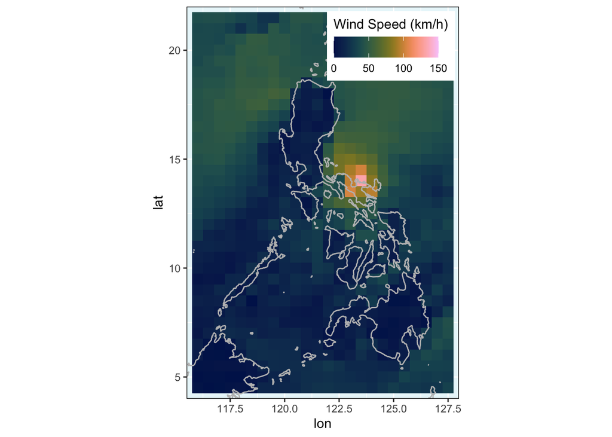

.

```r
# Plot wind speeds at 10 m elevation
ggplot() +
    geom_raster(data=wind_data,
                aes(x = lon, y = lat, fill = speed)) +
    scale_fill_scico(palette = 'batlow',
                     na.value = "transparent",
                     direction = 1,
                     name = "Wind Speed (km/h)",
                     limits = c(0,150),
                     guide = guide_colorbar(
                         direction = "horizontal",
                         title.position = "top")
                     ) +
    geom_path(data = coastlines_sim2_df, aes(x = long, y = lat, group = group), col="gray") +
    xlim(c(115.5, 128.0)) +
    ylim(c(4, 22.0)) +
    coord_equal(expand = 0) +
    theme(
        legend.position = c(0.75, 0.9),
        panel.background = element_rect(fill = "#EAF7FA"),
        panel.border = element_rect(colour = "black", fill = "transparent"),
        legend.background = element_rect(fill = "white")
    )
```

```r
ggsave(file= "Figures/wind_at_10m_kmh_map.png",
      scale = 2.0,
      width = 3, height = 4.5,
      dpi = 300)
```

## Extract wind speed value for each municipality

Here, we convert the windspeed to a raster, and load the municipality shapefile. It is important that both files have the same map projection.

```r
# Convert wind dataframe to raster
wind_data <- wind_data[c("lon", "lat", "speed")] # rearrange columns
wind_r <- rasterFromXYZ(wind_data)  # create raster; assumes first two columns as lon-lat and third as value

# Read the polygon shapefile of the municipalities to a table
muni_data <- sf::st_read(here("Data", "PH_municipality.shp"))
muni <- as(muni_data, "Spatial") # make a spatial polygons data frame
head(muni) %>% # show table
  kbl(caption = "Municipality data") %>%
  kable_classic(full_width = F, html_font = "Cambria")
```

Municipality data

| OBJECTID | Reg_Code | Reg_Name | Pro_Code | Pro_Name | Mun_Code | Mun_Name | Shape_Leng | Shape_Area | area | population | N_data | N_data_1 |
| --- | --- | --- | --- | --- | --- | --- | --- | --- | --- | --- | --- | --- |
| 1 | PH010000000 | REGION I (ILOCOS REGION) | PH012800000 | ILOCOS NORTE | PH012801000 | ADAMS | 0.4236039 | 0.0095060 | 117.12390 | 18640.363 | 3 | NA |
| 2 | PH010000000 | REGION I (ILOCOS REGION) | PH012800000 | ILOCOS NORTE | PH012802000 | BACARRA | 0.3091357 | 0.0047251 | 58.21789 | 9265.425 | 3 | NA |
| 3 | PH010000000 | REGION I (ILOCOS REGION) | PH012800000 | ILOCOS NORTE | PH012803000 | BADOC | 0.5992946 | 0.0068798 | 84.76583 | 13490.551 | 1 | NA |
| 4 | PH010000000 | REGION I (ILOCOS REGION) | PH012800000 | ILOCOS NORTE | PH012804000 | BANGUI | 0.4829115 | 0.0098429 | 121.27444 | 19300.924 | 5 | NA |
| 5 | PH010000000 | REGION I (ILOCOS REGION) | PH012800000 | ILOCOS NORTE | PH012805000 | CITY OF BATAC | 0.6134996 | 0.0134927 | 166.24371 | 26457.820 | 3 | NA |
| 6 | PH010000000 | REGION I (ILOCOS REGION) | PH012800000 | ILOCOS NORTE | PH012806000 | BURGOS | 0.5084007 | 0.0117284 | 144.50537 | 22998.147 | 4 | NA |

```r
# Define projection for mapping
WGS84 <- CRS("+proj=longlat +ellps=WGS84 +datum=WGS84")
crs(wind_r) <- WGS84
crs(muni) <- WGS84
```

The windspeed values from the raster can now be extracted and assigned to each municipality polygon. The `fun` argument controls what values of the raster pixels that fall in the polygon should be extracted. The function can be switched to `max` for example to get the maximum raster (windspeed) value that intersects the municipality polygon.

```r
Wind_Speed <- extract(wind_r, # raster layer
                      muni, # polygonsDF,
                      # buffer = NA, #optional
                      fun = mean, # what value to extract
                      na.rm = F)
```

We can add a column to the original municipality data table containing the extracted wind speed values.

```r
muni$Wind_Speed <- Wind_Speed

head(muni) %>% # show table
  kbl(caption = "Municipality data") %>%
  kable_classic(full_width = F, html_font = "Cambria")
```

Municipality data

| OBJECTID | Reg_Code | Reg_Name | Pro_Code | Pro_Name | Mun_Code | Mun_Name | Shape_Leng | Shape_Area | area | population | N_data | N_data_1 | Wind_Speed |
| --- | --- | --- | --- | --- | --- | --- | --- | --- | --- | --- | --- | --- | --- |
| 1 | PH010000000 | REGION I (ILOCOS REGION) | PH012800000 | ILOCOS NORTE | PH012801000 | ADAMS | 0.4236039 | 0.0095060 | 117.12390 | 18640.363 | 3 | NA | 10.76816 |
| 2 | PH010000000 | REGION I (ILOCOS REGION) | PH012800000 | ILOCOS NORTE | PH012802000 | BACARRA | 0.3091357 | 0.0047251 | 58.21789 | 9265.425 | 3 | NA | 31.27850 |
| 3 | PH010000000 | REGION I (ILOCOS REGION) | PH012800000 | ILOCOS NORTE | PH012803000 | BADOC | 0.5992946 | 0.0068798 | 84.76583 | 13490.551 | 1 | NA | 17.33879 |
| 4 | PH010000000 | REGION I (ILOCOS REGION) | PH012800000 | ILOCOS NORTE | PH012804000 | BANGUI | 0.4829115 | 0.0098429 | 121.27444 | 19300.924 | 5 | NA | 27.99318 |
| 5 | PH010000000 | REGION I (ILOCOS REGION) | PH012800000 | ILOCOS NORTE | PH012805000 | CITY OF BATAC | 0.6134996 | 0.0134927 | 166.24371 | 26457.820 | 3 | NA | 17.33879 |
| 6 | PH010000000 | REGION I (ILOCOS REGION) | PH012800000 | ILOCOS NORTE | PH012806000 | BURGOS | 0.5084007 | 0.0117284 | 144.50537 | 22998.147 | 4 | NA | 45.21821 |

This table, as a CSV file, can now be used as an input for the damage model.

```r
write.csv(muni,"Output_CSV/Municipalities_with_Windspeed_Mean.csv", row.names = F)
# write.csv(muni,"Output_CSV/Municipalities_with_Windspeed_Max.csv", row.names = F) # enable if extract function used max values
```

## Visualize wind speeds for each municipality

Finally, we can visualize the extracted windspeeds for all the municipalities as a map

```r
# add to data a new column termed "id" composed of the rownames of data
muni@data$id <- rownames(muni@data)
# create a data.frame from our spatial object
muniPoints <- fortify(muni, region = "id")
# merge the "fortified" data with the data from our spatial object
muniDF <- merge(muniPoints, muni@data, by = "id")
```

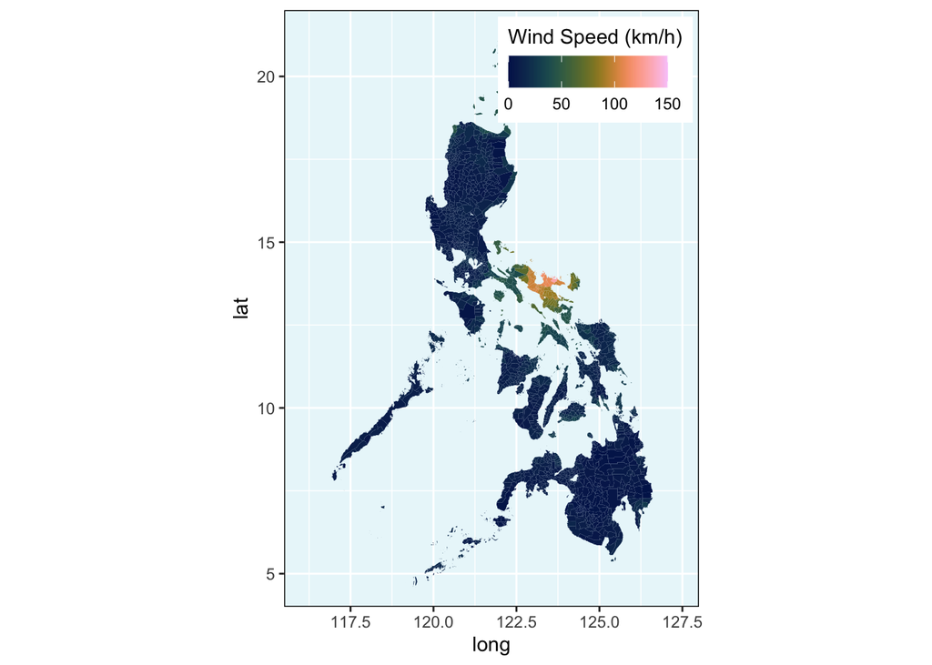

.

```r
ggplot(data = muniDF, aes(x=long, y=lat, group = group,
                          fill = Wind_Speed)) +
    geom_polygon()  +
    scale_fill_scico(palette = 'batlow',
                     na.value = "transparent",
                     direction = 1,
                     name = "Wind Speed (km/h)",
                     limits = c(0,150),
                     guide = guide_colorbar(
                         direction = "horizontal",
                         title.position = "top")
                     ) +
    xlim(c(115.5, 128.0)) +
    ylim(c(4, 22.0)) +
    coord_equal(expand = 0) +
    theme(
        legend.position = c(0.75, 0.9),
        panel.background = element_rect(fill = "#EAF7FA"),
        panel.border = element_rect(colour = "black", fill = "transparent"),
        legend.background = element_rect(fill = "white")
    )
```

```r
ggsave(file= "Figures/municipalities_with_windspeed_map.png",
      scale = 2.0,
      width = 3, height = 4.5,
      dpi = 300)
```

Wind velocity data can also be downloaded in the NOAA/NCEP website for the GFS model.